LAPORAN PRAKTIKUM METODE STATISTIKA

| Dosen: | Asisten: |
| --- | --- |
| Dr. Epha Diana Supandi, S.Si, M.Si. | 1. Hanifah Rahmawati |
|  | 2. Yogi Anggara |

# UTS PRAK. METODE STATISTIKA

4/26/2021

# Soal 1

`airquality` adalah dataset yang secara default telah disediaakan oleh R. Dataset ini berisikan pengukuran kualitas udara harian di New York pada bulan Mei sampai September 1973. Untuk penjelasan lebih lanjut, silahkan gunakan fitur `Help` pada R.

Dengan menggunakan dataset `airquality` , jawablah pertanyaan berikut:

## Bagian a

Tampilkan data observasi dengan kecepatan angin terkecil! Jika hasilnya lebih dari 1 baris, urutkan secara menaik berdasarkan tanggalnya. Pada tanggal berapa kecepatan angin berada di nilai paling rendah?

```r
wind.min = min(airquality$Wind)
subset(airquality, airquality$Wind == wind.min)
```

|  | Ozone | Solar.R | Wind | Temp | Month | Day |
| --- | --- | --- | --- | --- | --- | --- |
| 53 | NA | 59 | 1.7 | 76 | 6 | 22 |

## Bagian b

Buatlah plot garis rata-rata temperatur per bulan! Pada tanggal berapa suhu mengalami kenaikan paling besar?

```r
# sorry lagi mager bikin kode sendiri, jadi pake library aja :v
# pokoknya selama outputnya sesuai, benerin aja wkwk
# kalo belom install, jalanin dulu kode ini:
# install.packages("dplyr")
library(dplyr)
df = airquality %>%
        group_by(Month) %>%
        summarise(Temp.mean = mean(Temp)) %>%
        select(Month, Temp.mean)
```

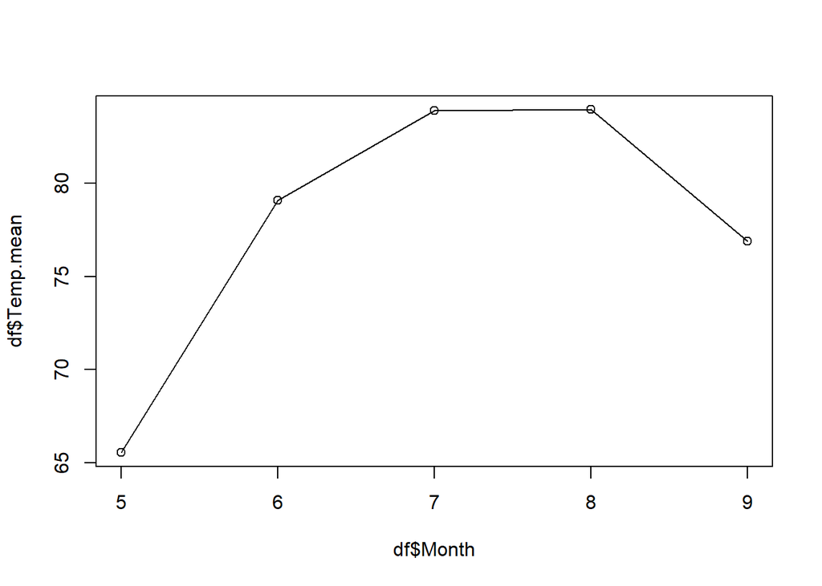

```r
plot(df$Month, df$Temp.mean, type = "o")
```

# Soal 2

Carilah peluang-peluang berikut ini :

## Bagian a

P(Z=2.5)

```r
dnorm(2.5,mean=0,sd=1)
```

```
## [1] 0.0175283
```

## Bagian b

P(Z≥2.5)

```r
pnorm(2.5, mean=0,sd=1,lower.tail=FALSE)
```

```
## [1] 0.006209665
```

## Bagian c

P(Z≤2.5)

```r
pnorm(2.5, mean=0,sd=1)
```

```
## [1] 0.9937903
```

## Bagian d

P(-2.5≤Z≤2.5)

```r
a=pnorm(-2.5,mean=0,sd=1)
b=pnorm(2.5,mean=0,sd=1)
b-a
```

```
## [1] 0.9875807
```